# Praca Domowa 2

Witold Merkel

18 03 2019

# 1 Wprowadzenie

Celem tego raportu jest opisane, a potem sprawdzenie czy `impact encoding` oraz `one-hot encoding` lub `łączenie rzadkich poziomów` wpłynie na poprawność algorytmu klastfikacji, który determiuje czy było płacone przy odbiorze. W całym raporcie pracuje na próbce o rozmiarz 10 000, w celu przyśpieszenia pracy.

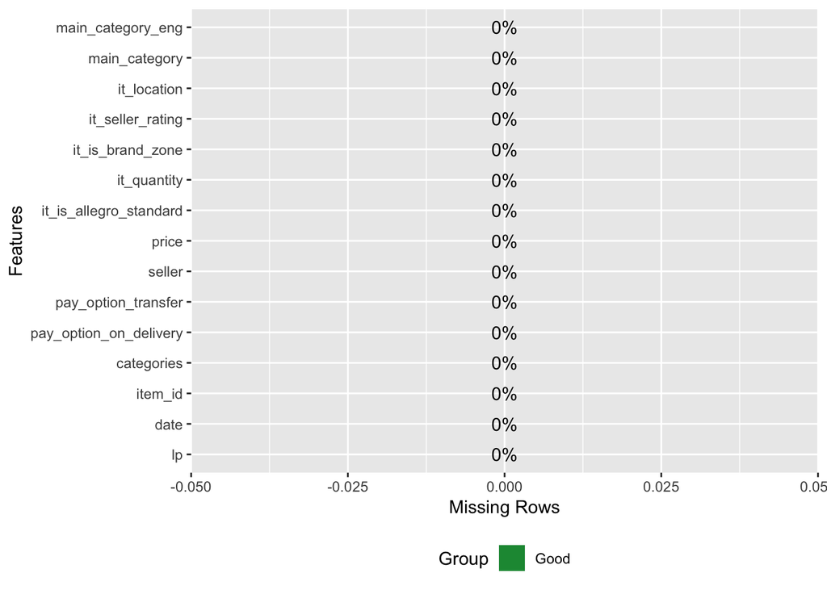

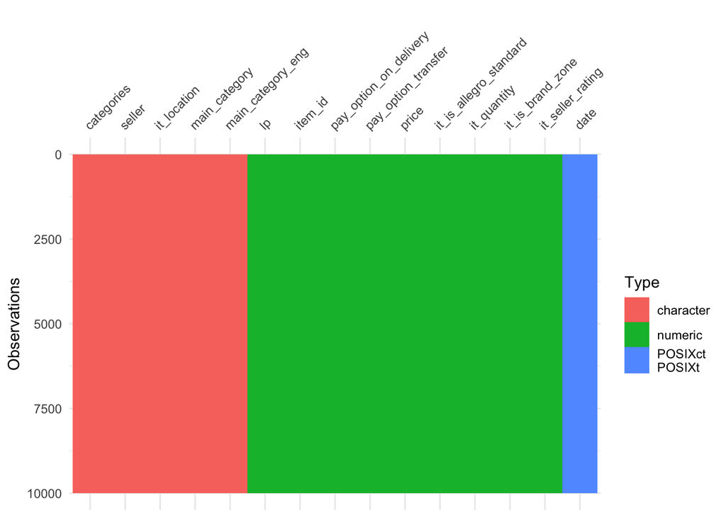

Jak widać dane nie posiadają braków, co znacznie ułatwi pracę, ponieważ część algorytmów nie pozwalan na `NA`.

# 2 Omówienie encodingu

|  | varName | sig | code |
| --- | --- | --- | --- |
| 1 | lp | 7.498464e-01 | clean |
| 2 | date | 6.303423e-06 | clean |
| 3 | item_id | 8.789892e-53 | clean |
| 4 | categories_catP | 2.398256e-02 | catP |
| 5 | categories_catB | 2.912548e-284 | catB |
| 6 | pay_option_transfer | 3.669002e-77 | clean |
| 7 | seller_catP | 7.850883e-02 | catP |
| 8 | seller_catB | 0.000000e+00 | catB |
| 9 | price | 8.719563e-04 | clean |
| 10 | it_is_allegro_standard | 1.655426e-149 | clean |

[output cut: 38 more lines]

Można zauważyć, że w naszym przypadku algorytm przekodował niektóre zmienne, więc będzie można zobaczyć czy to wpłynie na wynik algorytmu `classif.ada`.

## 2.1 Wartości liczbowe

```
## acc.test.mean auc.test.mean tpr.test.mean ppv.test.mean  f1.test.mean
##     0.9051000     0.8815221     0.3503139     0.6840531     0.4628755
```

```
## acc.test.mean auc.test.mean tpr.test.mean ppv.test.mean  f1.test.mean
##     0.9081000     0.8748207     0.3604914     0.7110396     0.4781318
```

Widać, że w przypadku tego konkretnego algorytmu kodowanie w żaden znaczący sposób nie wpłyneło na wartości tych metryk. Przyjrzyjmy się teraz krzywej `ROC` i zobaczmy jak wyglądają dla obu przypadów.

## 2.2 Wykresy

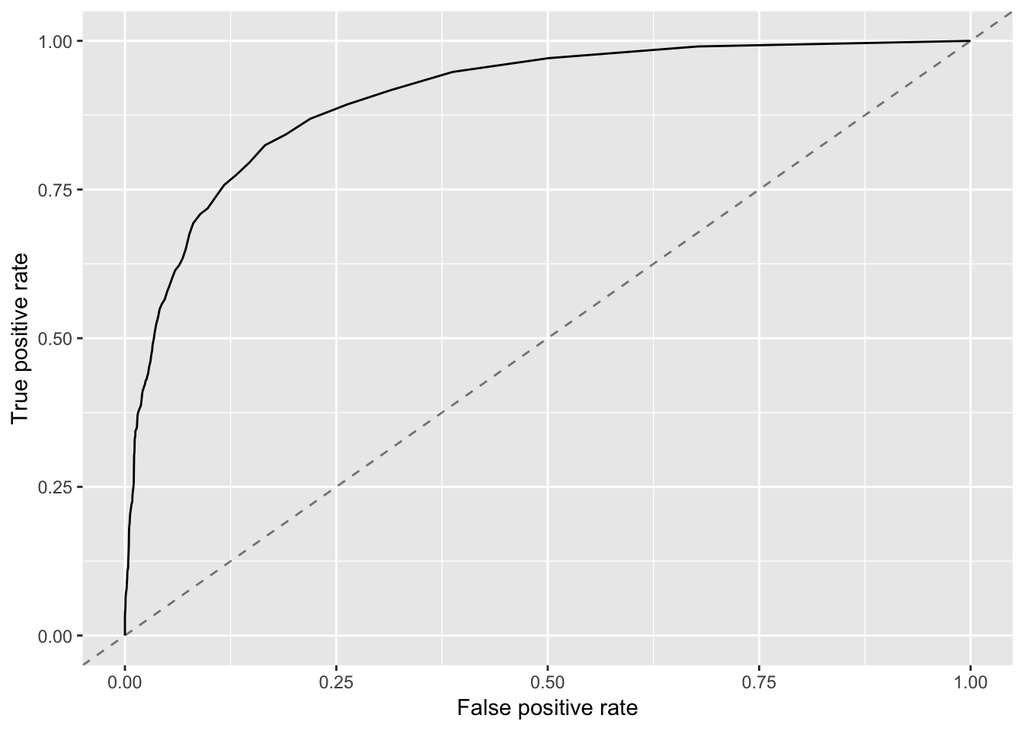

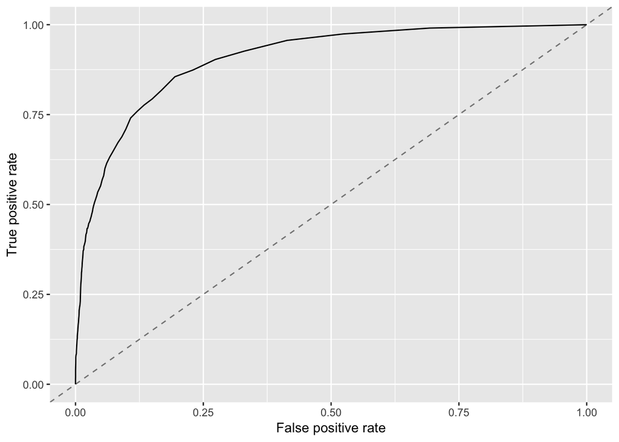

Krzywe na pierwszy rzut oka są takie same, dopiero po dokładnej obserwacji widać minimalne różnice, potwierdza to obserwacje z przed chwili.

# 3 Omówienie łączenia poziomów

Zdecydowałem się ograniczyć ilość poziomów zmiennej `categories` do 4, aby przetestować czy tak drastyczna zmiana (pierwotnie ponad 9000) jakoś wpłynie na wyniki.

## 3.1 Wartości liczbowe

```
## acc.test.mean auc.test.mean tpr.test.mean ppv.test.mean  f1.test.mean
##     0.9061000     0.8807758     0.3427845     0.7022673     0.4596315
```

```
## acc.test.mean auc.test.mean tpr.test.mean ppv.test.mean  f1.test.mean
##     0.9075000     0.8782280     0.3668544     0.7017054     0.4805640
```

Widać, że w przypadku tego konkretnego algorytmu kodowanie w żaden znaczący sposób nie wpłyneło na wartości tych metryk. Przyjrzyjmy się teraz krzywej `ROC` i zobaczmy jak wyglądają dla obu przypadów.

## 3.2 Wykresy

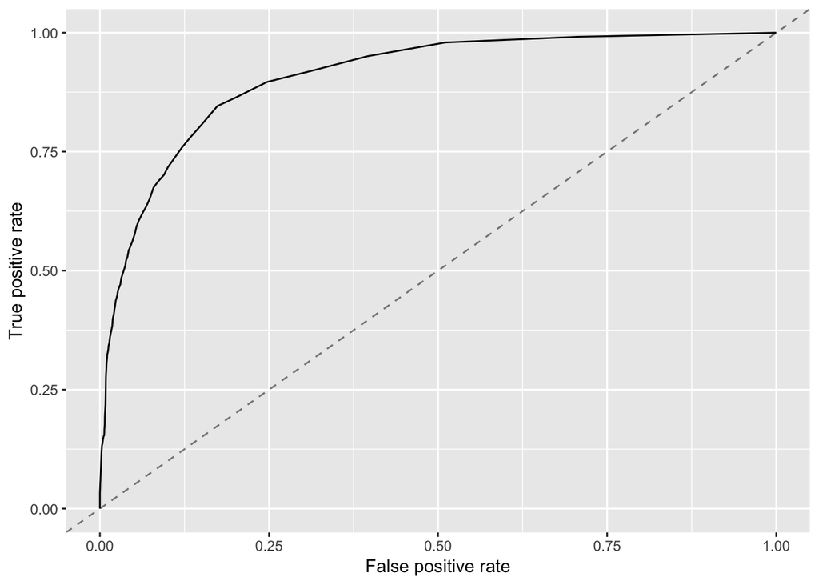

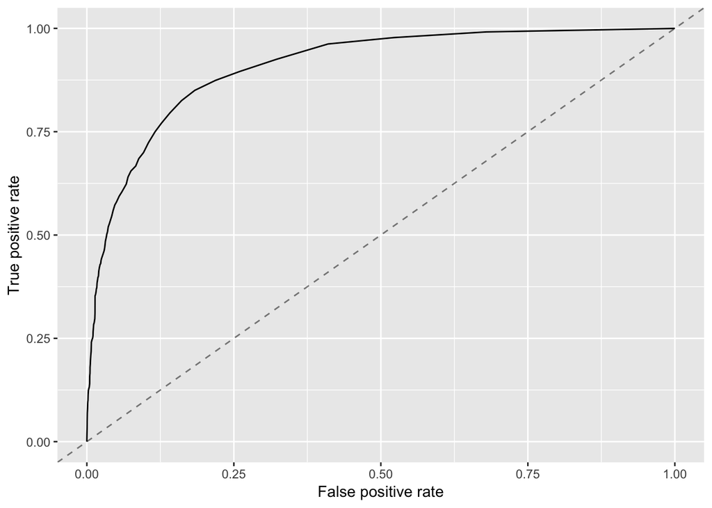

Krzywe na pierwszy rzut oka są takie same, dopiero po dokładnej obserwacji widać minimalne różnice, potwierdza to obserwacje z przed chwili.

# 4 Podsumowanie

Jak widać w tym przypadku, zmiana kodowania czy zmniejszenie ilości leveli na jednej zmienne znacząco nie wpłyneły na wyniki, jednak lekkie ulepszenie pokazuje, że w przypadku większego problemu w danych lub przy zmniejszeniu leveli wszędzie pozawala nam domyślać się, że ulepszenie będzie faktycznie większe.